# Name:- JENISH VINODBHAI DHADUK

## Student Id:- 989354198

# Project Name : Kellogg's olympics analysis

## 1. Objective of the proposed research.

```
kellogg's wants to sponsor an athlete in the next Olympics. So Kellogg's needs to identify the important information that can improve the quality of decision making for selecting an athlete. For that, a record of 120 years of Olympics history is given to analyze. It comprises all the results of Games from the 1896 Athens Olympics to 2016 Rio Olympics.

Being a multinational company targeting a specific candidate becomes very crucial. Olympics is a highly competitive event. All Countries comes on the same sporting platform to defeat one another as Kellogg’s has manufacturing facilities in more than 20 countries which are helping it to make its products available in more than 180 countries globally. Kellog's must make sure that by selecting some particular candidate they are not indirectly hurting any country's national sentiments.

For the world’s largest cereal maker and 2nd largest maker of cookies & snacks, sporting events that appeal to all age group specially among children is always going to be beneficial. Likewise for the company to be associated by a brand ambassador everything matters from how they show up on social media, and how is their's public image and most importantly how they perform on the field.

In this analysis, my goal is to select appropriate athlete and sporting event to whom Kellogg's can sponsor which might help them to exponentially increase their sells or help improves their brand image globally.
```

```r
library(tidyr)
library(dplyr)
```

# 2. Data exploration

```r
ath<-read.csv(file.choose())
head(ath)
```

| ID | Name | Sex | Age | Height | Weight | Team | NOC | Games | Year | Season | City | Sport | Event | Medal |
| --- | --- | --- | --- | --- | --- | --- | --- | --- | --- | --- | --- | --- | --- | --- |
| 1 | A Dijiang | M | 24 | 180 | 80 | China | CHN | 1992 Summer | 1992 | Summer | Barcelona | Basketball | Basketball Men's Basketball | NA |
| 2 | A Lamusi | M | 23 | 170 | 60 | China | CHN | 2012 Summer | 2012 | Summer | London | Judo | Judo Men's Extra-Lightweight | NA |
| 3 | Gunnar Nielsen Aaby | M | 24 | NA | NA | Denmark | DEN | 1920 Summer | 1920 | Summer | Antwerpen | Football | Football Men's Football | NA |
| 4 | Edgar Lindenau Aabye | M | 34 | NA | NA | Denmark/Sweden | DEN | 1900 Summer | 1900 | Summer | Paris | Tug-Of-War | Tug-Of-War Men's Tug-Of-War | Gold |
| 5 | Christine Jacoba Aaftink | F | 21 | 185 | 82 | Netherlands | NED | 1988 Winter | 1988 | Winter | Calgary | Speed Skating | Speed Skating Women's 500 metres | NA |
| 5 | Christine Jacoba Aaftink | F | 21 | 185 | 82 | Netherlands | NED | 1988 Winter | 1988 | Winter | Calgary | Speed Skating | Speed Skating Women's 1,000 metres | NA |

As per my research the three most viewed Sports are swimming, gymnatics and Athletics. So a athletic playing among these sports will have larger viewing audience as compare to any other sports.

```r
xath<-ath %>% filter(Medal =="Gold") %>% filter(Sport =="Swimming") %>%
  select(Year,Team,Medal) %>%
  group_by(Year,Team) %>%
  count(Medal) %>%
  group_by(Year) %>%
  arrange(Year,desc(n)) %>%
  slice(1:3)
```

Above code list out the country who won most gold medals in swimming category.

```r
#table 1
tail(xath,n=12)

#number of rows in table
nrow(xath)

#number of columns in table
ncol(xath)
```

[output not shown]

54

Table 1

```r
xath<-ath %>% filter(Medal =="Gold") %>% filter(Sport =="Gymnastics") %>%
  select(Year,Team,Medal) %>%
  group_by(Year,Team) %>%
  count(Medal) %>%
  group_by(Year) %>%
  arrange(Year,desc(n)) %>%
  slice(1:3)
```

```r
#table 2
tail(xath,n=6)
#number of rows in table
nrow(xath)

#number of columns in table
ncol(xath)
```

| Year | Team | Medal | n |
| --- | --- | --- | --- |
| 2012 | China | Gold | 8 |
| 2012 | United States | Gold | 7 |
| 2012 | Brazil | Gold | 1 |
| 2016 | United States | Gold | 8 |
| 2016 | Japan | Gold | 6 |
| 2016 | Great Britain | Gold | 2 |

84

4

Table 2

In the above table United States have won 7 gold medals and 8 gold medals in 2012 and 2016 respectively. It shows the potentail of american athletics in the last two olympics.

```r
xath<-ath %>% filter(Medal =="Gold") %>% filter(Sport =="Athletics") %>%
  select(Year,Team,Medal) %>%
  group_by(Year,Team) %>%
  count(Medal) %>%
  group_by(Year) %>%
  arrange(Year,desc(n)) %>%
  slice(1:3)
```

```r
#table 3
#showing the last 6 rows of the table
tail(xath,n=6)
```

| Year | Team | Medal | n |
| --- | --- | --- | --- |
| 2012 | United States | Gold | 19 |
| 2012 | Jamaica | Gold | 8 |
| 2012 | Russia | Gold | 8 |
| 2016 | United States | Gold | 27 |
| 2016 | Jamaica | Gold | 11 |
| 2016 | Kenya | Gold | 6 |

Table 3

The above table shows the gold medals won in last two olympics in Athletics. Here United States and Jamacian athletics have proven their ability to win medals.

The above analysis shows the best performing nations for most viewd sports in olympics is carried out. Now to find the best athletics in the respective sports, further analysis needs to be carried out.

```r
xath<-ath %>% filter(Medal !="<NA>") %>% filter(Sport =="Swimming") %>%
  filter(Team =="Australia") %>%
  select(Year,Name,Team,Medal,Age,Sex) %>%
  group_by(Year,Name,Team,Age,Sex) %>%
  count(Medal) %>%
  group_by(Year) %>%
  arrange(Year,desc(n)) %>%
  slice(1:7)
tail(xath,n=12)
```

| Year | Name | Team | Age | Sex | Medal | n |
| --- | --- | --- | --- | --- | --- | --- |
| 2012 | Emily Jane Seebohm | Australia | 20 | F | Silver | 2 |
| 2012 | Melanie Rene "Mel" Schlanger (-Wright) | Australia | 25 | F | Silver | 2 |
| 2012 | Alicia Jayne Coutts | Australia | 24 | F | Bronze | 1 |
| 2012 | Alicia Jayne Coutts | Australia | 24 | F | Gold | 1 |
| 2012 | Angie Lee Bainbridge | Australia | 22 | F | Silver | 1 |
| 2016 | Cameron McEvoy | Australia | 22 | M | Bronze | 2 |
| 2016 | Emma McKeon | Australia | 22 | F | Silver | 2 |
| 2016 | Kyle Chalmers | Australia | 18 | M | Bronze | 2 |
| 2016 | Madeline Groves | Australia | 21 | F | Silver | 2 |
| 2016 | Brittany Joyce Elmslie | Australia | 22 | F | Gold | 1 |
| 2016 | Brittany Joyce Elmslie | Australia | 22 | F | Silver | 1 |
| 2016 | Bronte Amelia Arnold Barratt | Australia | 27 | F | Silver | 1 |

Here It shows the medals won by australian swimmers in last two olympics.

The two candidates that can be recommended to kellogg's from Australia because they have won 2-2 medals each in last olympics. 1.Emma McKeon  
2.Brittany Joyce Elmslie

# 3. One colum selection

```r
ath<-read.csv(file.choose())
```

lets find out the largest value in the "AGE" column from the data set to see the list of oldest participant's ever participated in the olympics.

```r
xath<-ath %>% filter(Age != "<NA>") %>% arrange(Age) %>% select(Age) %>%
  group_by(Age)
tail(xath,n=10)
```

| Age |
| --- |
| 80 |
| 80 |
| 81 |
| 81 |
| 84 |
| 88 |
| 88 |
| 88 |
| 96 |
| 97 |

This One-column gives the age of the 10 oldest participants ever participated in the the olympics.

# 4.series

```r
xath<-ath %>% filter(Medal !="<NA>") %>% filter(Sport =="Swimming") %>%
  filter(Team =="United States") %>%
  select(Year,Name,Team,Medal,Age,Sex) %>%
  group_by(Year,Name,Team,Age,Sex) %>%
  count(Medal) %>%
  group_by(Year) %>%
  arrange(Year,desc(n)) %>%
  slice(1:7)
tail(xath,n=12)
```

| Year | Name | Team | Age | Sex | Medal | n |
| --- | --- | --- | --- | --- | --- | --- |
| 2012 | Allison Rodgers Schmitt | United States | 22 | F | Gold | 3 |
| 2012 | Dana Whitney Vollmer (-Grant) | United States | 24 | F | Gold | 3 |
| 2012 | Cullen Andrew Jones | United States | 28 | M | Silver | 2 |
| 2012 | Matthew "Matt" Grevers | United States | 27 | M | Gold | 2 |
| 2012 | Michael Fred Phelps, II | United States | 27 | M | Silver | 2 |
| 2016 | Michael Fred Phelps, II | United States | 31 | M | Gold | 5 |
| 2016 | Kathleen Genevieve "Katie" Ledecky | United States | 19 | F | Gold | 4 |
| 2016 | Ryan Murphy | United States | 21 | M | Gold | 3 |
| 2016 | Anthony Lee Ervin | United States | 35 | M | Gold | 2 |
| 2016 | Caeleb Remel Dressel | United States | 19 | M | Gold | 2 |
| 2016 | Lilly King | United States | 19 | F | Gold | 2 |
| 2016 | Madeline Jane "Maya" DiRado | United States | 23 | F | Gold | 2 |

This table has 7 columns including:-

Year:- It shows the year in which the olympics was played which will be helpful for kellogg's to figure out which athletic is performing well in present time.

Name:- It contains the name of swimmers who have won any kind of medals in the olympics.

Team:- It includes the name of the nation which will help kellogg's to know that which athletic belong to which country.

Age:- This column includes the age of the athletics by which kellogg's can know how experienced are the athletes.

Sex:- Displays the gender of the athletics which will come handy to kellogg's if they are considering to launch some gender specific product meals.

Medal:- Shows the category of the medal won by athletics.

n:- Displays the count of medal won by the athletics.

It shows the medals won by american swimmers in last two olympics. The three candidates kellogg's should choose. If they are considering american swimmers. 1.Ryan Murphy 2.Kathleen Genevieve "Katie" Ledecky 3.Michael Fred Phelps, II

```r
xath<-ath %>% filter(Medal !="<NA>") %>% filter(Sport =="Athletics") %>%
  filter(Team =="United States") %>%
  select(Year,Name,Team,Medal,Age,Sex) %>%
  group_by(Year,Name,Team,Age,Sex) %>%
  count(Medal) %>%
  group_by(Year) %>%
  arrange(Year,desc(n)) %>%
  slice(1:7)
tail(xath,n=12)
```

| Year | Name | Team | Age | Sex | Medal | n |
| --- | --- | --- | --- | --- | --- | --- |
| 2012 | Angelo F. Taylor, Jr. | United States | 33 | M | Silver | 1 |
| 2012 | Aries D'Andre Merritt | United States | 27 | M | Gold | 1 |
| 2012 | Ashton James Eaton | United States | 24 | M | Gold | 1 |
| 2012 | Bianca Knight | United States | 23 | F | Gold | 1 |
| 2012 | Brigetta LaShea Barrett | United States | 21 | F | Silver | 1 |
| 2016 | Allyson Michelle Felix | United States | 30 | F | Gold | 2 |
| 2016 | Tianna Madison-Bartoletta | United States | 30 | F | Gold | 2 |
| 2016 | Allyson Michelle Felix | United States | 30 | F | Silver | 1 |
| 2016 | Arman Hall | United States | 22 | M | Gold | 1 |
| 2016 | Ashley Spencer | United States | 23 | F | Bronze | 1 |
| 2016 | Ashton James Eaton | United States | 28 | M | Gold | 1 |
| 2016 | Brianna Rollins | United States | 24 | F | Gold | 1 |

This table gives the name of the american athletics who won medals in last two olympics. The definite option for kellogg's to consider from this output is as follows: 1.Allyson Michelle Felix

```r
xath<-ath %>% filter(Medal !="<NA>") %>% filter(Sport =="Athletics") %>%
  filter(Team =="Jamaica") %>%
  select(Year,Name,Team,Medal,Age,Sex) %>%
  group_by(Year,Name,Team,Age,Sex) %>%
  count(Medal) %>%
  group_by(Year) %>%
  arrange(Year,desc(n)) %>%
  slice(1:7)
tail(xath,n=14)
```

| Year | Name | Team | Age | Sex | Medal | n |
| --- | --- | --- | --- | --- | --- | --- |
| 2012 | Usain St. Leo Bolt | Jamaica | 25 | M | Gold | 3 |
| 2012 | Shelly-Ann Fraser-Pryce | Jamaica | 25 | F | Silver | 2 |
| 2012 | Yohan Blake | Jamaica | 22 | M | Silver | 2 |
| 2012 | Christine Day | Jamaica | 25 | F | Bronze | 1 |
| 2012 | Hansle George Parchment | Jamaica | 22 | M | Bronze | 1 |
| 2012 | Kemar Bailey-Cole | Jamaica | 20 | M | Gold | 1 |
| 2012 | Kerron Stewart | Jamaica | 28 | F | Silver | 1 |
| 2016 | Usain St. Leo Bolt | Jamaica | 29 | M | Gold | 3 |
| 2016 | Elaine Thompson | Jamaica | 24 | F | Gold | 2 |
| 2016 | Anneisha McLaughlin-Whilby | Jamaica | 30 | F | Silver | 1 |
| 2016 | Asafa Kehine Powell | Jamaica | 33 | M | Gold | 1 |
| 2016 | Chrisann Gordon | Jamaica | 21 | F | Silver | 1 |
| 2016 | Christania Williams | Jamaica | 21 | F | Silver | 1 |
| 2016 | Christine Day | Jamaica | 29 | F | Silver | 1 |

This table shows the medals won by Jamaican athletics in last two olympics. The two picks from jamacian athletics as they have won more medals than their peers are. 1.Usain Bolt 2.Elaine Thompson

```r
xath<-ath %>% filter(Medal !="<NA>") %>% filter(Sport =="Gymnastics") %>%
  filter(Team =="United States") %>%
  select(Year,Name,Team,Medal,Age,Sex) %>%
  group_by(Year,Name,Team,Age,Sex) %>%
  count(Medal) %>%
  group_by(Year) %>%
  arrange(Year,desc(n)) %>%
  slice(1:7)
tail(xath,n=14)
```

| Year | Name | Team | Age | Sex | Medal | n |
| --- | --- | --- | --- | --- | --- | --- |
| 2012 | Alexandra Rose "Aly" Raisman | United States | 18 | F | Gold | 2 |
| 2012 | Gabrielle Christina Victoria "Gabby" Douglas | United States | 16 | F | Gold | 2 |
| 2012 | Alexandra Rose "Aly" Raisman | United States | 18 | F | Bronze | 1 |
| 2012 | Danell Johan Leyva Gonzalez | United States | 20 | M | Bronze | 1 |
| 2012 | Jordyn Marie Wieber | United States | 17 | F | Gold | 1 |
| 2012 | Kyla Briana Ross | United States | 15 | F | Gold | 1 |
| 2012 | McKayla Rose Maroney | United States | 16 | F | Gold | 1 |
| 2016 | Simone Arianne Biles | United States | 19 | F | Gold | 4 |
| 2016 | Alexandra Rose "Aly" Raisman | United States | 22 | F | Silver | 2 |
| 2016 | Danell Johan Leyva Gonzalez | United States | 24 | M | Silver | 2 |
| 2016 | Alexander Michael "Alex" Naddour | United States | 25 | M | Bronze | 1 |
| 2016 | Alexandra Rose "Aly" Raisman | United States | 22 | F | Gold | 1 |
| 2016 | Gabrielle Christina Victoria "Gabby" Douglas | United States | 20 | F | Gold | 1 |
| 2016 | Lauren Zoe "Laurie" Hernandez | United States | 16 | F | Gold | 1 |

# 5. Plot

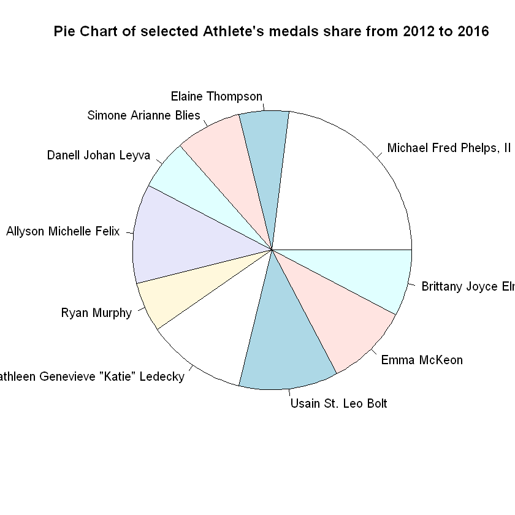

```r
All_ath <- c("Michael Fred Phelps, II","Elaine Thompson","Simone Arianne Blies","Danell Johan Leyva","Allyson Michelle Felix","Ryan Murphy",'Kathleen Genevieve "Katie" Ledecky',"Usain St. Leo Bolt","Emma McKeon","Brittany Joyce Elmslie")
medalcount <-c(12,3,4,3,6,3,6,6,5,4)
pie(medalcount, labels = All_ath, main="Pie Chart of selected Athlete's medals share from 2012 to 2016")
```

# 6.Summary

To summarize the analysis, the operations were performed on the datasets of the most viewed sports in the olympics history and they were Gymnastics, Athletics and Swimming. So after selecting the sporting event, the best performer in terms of nation were shortlisted for all three sports. Following the same trend, best performing athletics in the last couple of years in the respective nation are shortlisted. Atlast a final draft of the 10 athletes are selected to be given as recommendation to Kellogg's to sponsor in the next olympics.

# 7.Recommendations

Here are the 10 athletes that are shortlisted after analyzing the dataset and performing the various operation in detail. As these athletes have performed well in the recent olympics, the athelets are most likely to attract the attention of more viewers. All belongs to the most viewed sports of the olympics history.  
Usain Bolt and Elaine Thompson, Simone Arianne Blies and Danell Johan Leyva, Allyson Michelle Felix, Ryan Murphy,Kathleen Genevieve "Katie" Ledecky, Michael Fred Phelps, II, Emma McKeon and Brittany Joyce Elmslie